# Week 10 Panel Data and Difference-in-Differences

Author

Zhe Chen

# The Core Idea

Observe the same unit before and after treatment.

- What is stable about the unit (ability, upbringing) is the same in both periods, so the before–after change removes it, measured or not: fixed effects.
- What changes for everyone (a recession, getting older) does not cancel, but units that were not treated went through it too, so their change measures it: difference-in-differences.

# Panel Data

## Example: Does Marriage Raise Men’s Wages

**Question**: Married men earn more than unmarried men. Is it marriage (specialization at home, employers’ favour), or do men with high earning potential marry?

**Data**: NLSY men observed every year 1980–87; 545 men; 4,360 person-years; $Y_{it}$: log hourly wage of man $i$ in year $t$; $D_{it} = 1$ if married that year.

| men never married in the panel | 162 |
| --- | --- |
| men married in all eight years | 73 |
| men whose status changes | 310 |
| share married, 1980 → 1987 | 0.19 → 0.61 |
| mean log wage, 1980 → 1987 | 1.39 → 1.87 |

## Pooled OLS $\bigstar$

Treat the 1,056 person-years (528 men, 1980 and 1987) as if they were 1,056 different men:

$$Y_{it} = a + \beta D_{it} + u_{it},
\qquad
\hat{\beta} = 0.358 (0.031)$$

Married men earn about 43% more.

$$\operatorname{plim}\hat{\beta}
= \beta + \frac{\operatorname{Cov}(D_{it},u_{it})}
{\operatorname{Var}(D_{it})}$$

Now we do not consider the omitted variables $u_{it}$ (Week 2)

- $u_{it}$ holds everything else that sets man $i$’s wage in year $t$:
  - *stable* traits: ability, ambition, schooling, family background;
  - what *changes over time*: experience, seniority, prices, the economy.
- Both can move with marriage: men with high-wage traits may marry more, and men marry as they age while every man’s wage grows. Either way $\operatorname{Cov}(D_{it},u_{it}) > 0$ and 0.358 is too big.
- We cannot measure all of them. But we see each man more than once.

# Fixed Effects

## Two-wave Case $\bigstar$

### Split the error in three

$u_{it}=\alpha_i+\lambda_t+\epsilon_{it}$.

- $\alpha_i$: the combined effect on his wage of *everything stable* about man $i$ (ability, ambition, schooling, family background), measured or not.
- $\lambda_t$: what changes for *every* man in year $t$ (experience, prices).
- $\epsilon_{it}$: the rest.

### Take 1987 and 1980

$$\begin{aligned}
Y_{i,87} &= \alpha_i+\lambda_{87}+\beta D_{i,87}+\epsilon_{i,87}
&& \text{1987}\\
Y_{i,80} &= \alpha_i+\lambda_{80}+\beta D_{i,80}+\epsilon_{i,80}
&& \text{1980}\\
Y_{i,87}-Y_{i,80}
&= \underbrace{(\lambda_{87}-\lambda_{80})}_{\text{intercept}}
+\beta(D_{i,87}-D_{i,80})
+(\epsilon_{i,87}-\epsilon_{i,80})
&& \text{subtract: }\alpha_i\text{ cancels}
\end{aligned}$$

**First differences:** regress each man’s wage growth on his change in marital status, with an intercept. **Idea 1: compare each man with himself.** Every stable trait is gone, measured or not.

### Men Who Did Not Change Are the Control Group

| Change in married, 1980 $\rightarrow$ 1987 | Men | Mean wage growth |
| --- | --- | --- |
| Married ($\Delta D=1$) | 251 | 0.488 |
| No change ($\Delta D=0$) | 277 | 0.476 |

OLS: $\hat{\lambda}_{87}-\hat{\lambda}_{80}=0.476\ (0.037),\quad \hat{\beta}=0.012\ (0.053).$

- The intercept is the year effect, $\lambda_{87}-\lambda_{80}$, estimated from the 277 men whose status did not change. **Idea 2: the year fixed effect makes them the control group.**
- $\hat{\beta}=0.488-0.476$ is the *extra growth* of men who married: difference-in-differences. If the timing of marriage were random, this is the comparison an experiment would make.
- Pooled OLS said 0.358. Most of it was stable traits and common growth.

### All Men, All Years: The Model

Now all 545 men (the 17 who left marriage too) and every year, $t=1980,\ldots,1987$:

$$Y_{it}
=
\underbrace{\alpha_i}_{\text{who he is}}
+
\underbrace{\lambda_t}_{\text{what year it is}}
+
\underbrace{\beta D_{it}}_{\text{marriage}}
+
\underbrace{\epsilon_{it}}_{\text{everything else}}.$$

- $\alpha_i$: one number per man, for everything stable about him (ability, ambition, family background), measured or not: **man fixed effects**.
- $\lambda_t$: one number per year, for what happens to every man that year (the economy, a year more experience): **year fixed effects**.
- With both sets of fixed effects in the model, people call it **two-way fixed effects (TWFE)**.

## Visual Illustrations

### Man Fixed Effects: Each Man His Own Line

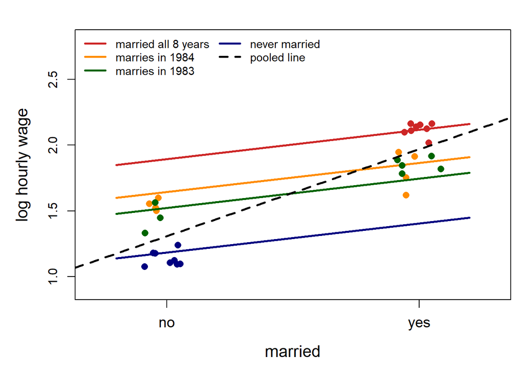

$Y_{it}=\alpha_i+\beta D_{it}+\epsilon_{it}$: one dummy per man, one common slope. Four of the men:

- The pooled line (slope 0.66 for these four) mostly compares *different men*: the high-wage men are the married ones.
- Each colored line is one man at his own height $\hat{\alpha}_i$. Its slope (0.31 for these four) compares him only with himself: married years vs. unmarried years.
- All 545 men: $\hat{\beta}=0.243\ (0.022)$. But a man’s married years are also his later years, when every wage is higher.

#### Year Fixed Effects: One Common Year Path

$Y_{it}=a+\lambda_t+\beta D_{it}+\epsilon_{it}$: one dummy per year, the same for every man.

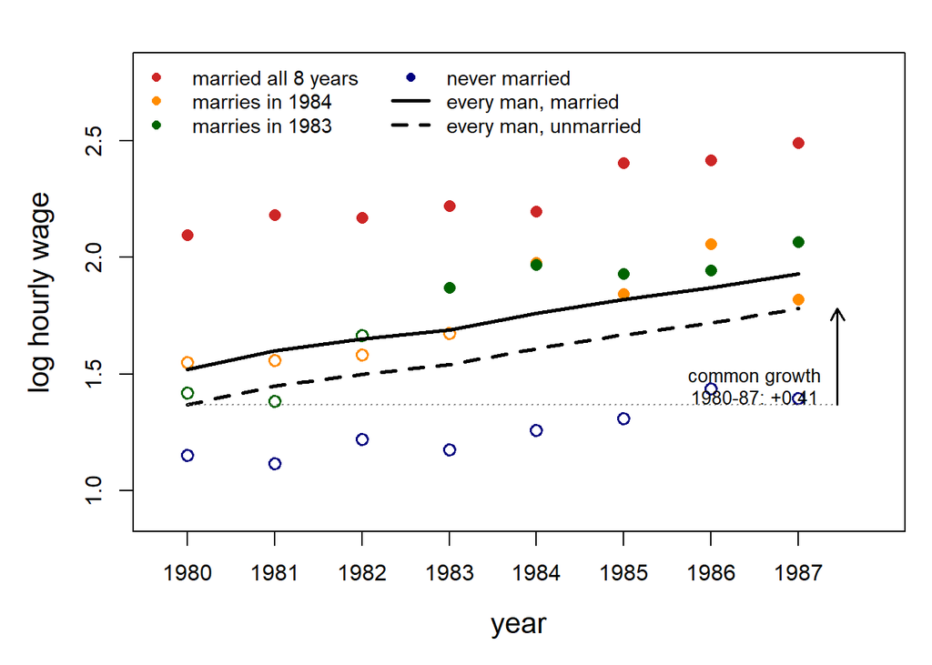

- **Dashed:** $\hat{a}+\hat{\lambda}_t$, the wage of an unmarried man in year $t$. It rises 0.41 from 1980 to 1987: growth *every* man gets, married or not.
- **Solid:** the same path plus $\hat{\beta}=0.150\ (0.028)$ in married years.
- But every man shares one line: the red man is high in every year, married or not, so $\hat{\beta}$ still compares *different men*.

### Two-Way FE: Own Level, Common Year Path

$Y_{it}=\alpha_i+\lambda_t+\beta D_{it}+\epsilon_{it}$. Fitted on all 545 men; four of them shown:

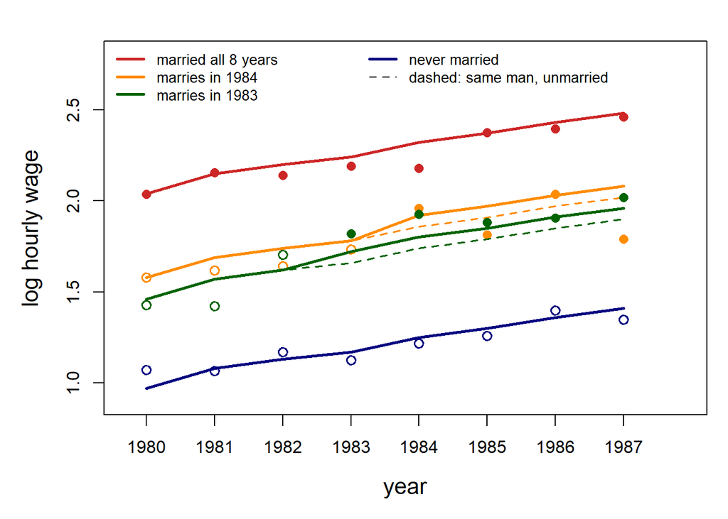

- Every man follows the same year path, shifted to his own level.
- Marriage lifts him off his own path: the gap between solid and dashed.
- $\hat{\beta}=0.061\ (0.022)$. Filled points: married years.

## Two-Way FE Can Be Demeaned

### The Algebra (not evaluated)

Subtract the man’s mean and the year’s mean. In a balanced panel:

$$\begin{aligned}
Y_{it}
&= \alpha_i+\lambda_t+\beta D_{it}+\epsilon_{it}
&& \text{the model}\\[4pt]
\bar{Y}_{i\cdot}
&= \alpha_i+\bar{\lambda}+\beta\bar{D}_{i\cdot}+\bar{\epsilon}_{i\cdot}
&& \text{average over }t:\text{ man's mean}\\[4pt]
\bar{Y}_{\cdot t}
&= \bar{\alpha}+\lambda_t+\beta\bar{D}_{\cdot t}+\bar{\epsilon}_{\cdot t}
&& \text{average over }i:\text{ year }t\text{'s mean}\\[4pt]
\bar{Y}
&= \bar{\alpha}+\bar{\lambda}+\beta\bar{D}+\bar{\epsilon}
&& \text{average over both}\\[6pt]
Y_{it}-\bar{Y}_{i\cdot}-\bar{Y}_{\cdot t}+\bar{Y}
&= \beta\left(D_{it}-\bar{D}_{i\cdot}-\bar{D}_{\cdot t}+\bar{D}\right)
+\ddot{\epsilon}_{it}
&& \text{line }1-2-3+4:\ \alpha_i\text{ and }\lambda_t\text{ cancel}
\end{aligned}$$

- **Double demeaning:** subtract the man’s mean and the year’s mean, add back the grand mean (subtracted twice). Same $\hat{\beta}$ as man and year dummies: **0.0606** both ways.
- With only 1980 and 1987 (528 men) it gives **0.012**, the same as first differences.

### In Software

Man 1 marries in 1982; man 2 never does. Omitted dummies: man 2 and 1980.

**The data**

| Man | Year | $Y$ | $D$ | Man 1 | 1981 | 1982 |
| --- | --- | --- | --- | --- | --- | --- |
| 1 | 1980 | 1.5 | 0 | 1 | 0 | 0 |
| 1 | 1981 | 1.8 | 0 | 1 | 1 | 0 |
| 1 | 1982 | 2.4 | 1 | 1 | 0 | 1 |
| 2 | 1980 | 1.2 | 0 | 0 | 0 | 0 |
| 2 | 1981 | 1.5 | 0 | 0 | 1 | 0 |
| 2 | 1982 | 1.8 | 0 | 0 | 0 | 1 |

**The man’s mean of each column**

| $\bar{Y}$ | $\bar{D}$ | Man 1 | 1981 | 1982 |
| --- | --- | --- | --- | --- |
| 1.9 | $\frac{1}{3}$ | 1 | $\frac{1}{3}$ | $\frac{1}{3}$ |
| 1.9 | $\frac{1}{3}$ | 1 | $\frac{1}{3}$ | $\frac{1}{3}$ |
| 1.9 | $\frac{1}{3}$ | 1 | $\frac{1}{3}$ | $\frac{1}{3}$ |
| 1.5 | 0 | 0 | $\frac{1}{3}$ | $\frac{1}{3}$ |
| 1.5 | 0 | 0 | $\frac{1}{3}$ | $\frac{1}{3}$ |
| 1.5 | 0 | 0 | $\frac{1}{3}$ | $\frac{1}{3}$ |

- Subtract right from left, row by row: the man 1 column becomes all 0, so subtracting means does the man dummies’ job.
- What is left of $Y$ is each man’s distance from his own average: **TWFE compares each man with himself over time.**
- Man 2 gives the year path $(+0.3,+0.6)$; man 1 grew $0.9$: $\hat{\beta}=0.3$.

Man effects only, binary $D$. Run the within regression for *one* man:

$$b_i=(\text{his mean wage in married years})-(\text{his mean wage in unmarried years}),$$

because a regression on one 0/1 variable with an intercept is a difference in means (Week 1). **Example** (hypothetical): married in 3 of 8 years.

|  | Log wages | Mean |
| --- | --- | --- |
| 5 unmarried years | 1.50, 1.55, 1.60, 1.62, 1.63 | 1.58 |
| 3 married years | 1.70, 1.75, 1.80 | 1.75 |
| $b_i$ |  | $1.75-1.58=0.17$ |

- A man who never changes status has no $b_i$: he adds nothing.
- Fixed effects combines the 310 men’s $b_i$ into one number. The question is how it weights them.

### Weights

#### Step 1: Fixed Effects Is an Average of the $b_i$

Tilde: minus the man’s own mean. Write man $i$’s piece of the fixed-effects formula as $N_i=\sum_t\widetilde{D}_{it}\widetilde{Y}_{it}$ (numerator) and $S_i=\sum_t\widetilde{D}_{it}^2$ (denominator):

$$\begin{aligned}
\hat{\beta}_{FE}
&=\frac{\sum_i\sum_t\widetilde{D}_{it}\widetilde{Y}_{it}}
{\sum_i\sum_t\widetilde{D}_{it}^2}
=\frac{N_1+N_2+\cdots}{S_1+S_2+\cdots}
&& \text{add up man by man}\\[6pt]
b_i&=N_i/S_i,\qquad \text{so }N_i=S_i b_i
&& \text{man }i\text{'s own regression}\\[6pt]
\hat{\beta}_{FE}
&=\frac{S_1b_1+S_2b_2+\cdots}{S_1+S_2+\cdots}
=\sum_i w_i b_i,\qquad
w_i=\frac{S_i}{S_1+S_2+\cdots}
&& \text{substitute}
\end{aligned}$$

- Fixed effects is a **weighted average** of the men’s own estimates $b_i$.
- Man $i$’s weight is his $S_i$, the variation in his own marriage status, as a share of everyone’s.

#### Step 2: What a Man’s $S_i$ Is

Man $i$ is married in $m_i$ of $T$ years, so $\bar{D}_i=m_i/T=p_i$. His demeaned 0/1 values:

$$\begin{aligned}
\widetilde{D}_{it}
&=1-p_i
&& \text{in his }m_i\text{ married years}\\
\widetilde{D}_{it}
&=-p_i
&& \text{in his }T-m_i\text{ unmarried years}\\[4pt]
S_i
&=m_i(1-p_i)^2+(T-m_i)p_i^2
&& \text{square and add}\\
&=Tp_i(1-p_i)^2+T(1-p_i)p_i^2
=Tp_i(1-p_i)
&& m_i=Tp_i;\text{ factor out }Tp_i(1-p_i)
\end{aligned}$$

**Check:** $T=8$, married 2 years, $p=0.25$:

$$2(0.75)^2+6(0.25)^2=1.125+0.375=1.5=8(0.25)(0.75).$$

| Years married, of 8 | 1 | 2 | 3 | 4 | 5 | 6 | 7 |
| --- | --- | --- | --- | --- | --- | --- | --- |
| Weight per man, $8p(1-p)$ | 0.88 | 1.50 | 1.88 | 2.00 | 1.88 | 1.50 | 0.88 |
| Share of total weight | .08 | .11 | .19 | .15 | .22 | .14 | .12 |

Largest for men married half the time; a man married 1 of 8 years counts less than half as much.

#### Step 3: Two Men

|  | Married | Own estimate $b_i$ | Weight $S_i=8p(1-p)$ |
| --- | --- | --- | --- |
| Man A | 4 of 8 years | 0.10 | 2.000 |
| Man B | 1 of 8 years | 0.40 | 0.875 |

$$\begin{aligned}
\hat{\beta}_{FE}
&=\frac{2.000\times0.10+0.875\times0.40}{2.000+0.875}
=\frac{0.55}{2.875}=0.19\\[6pt]
\text{Plain average}
&=\frac{0.10+0.40}{2}=0.25
\end{aligned}$$

- Fixed effects leans toward man A, whose status varies more, not toward the typical man. If effects differ across men, **FE is not the average effect**.

## Two-Way FE Assumptions $\bigstar$

$$Y_{it}
=
\beta D_{it}
+
\underbrace{\alpha_i}_{\text{stable: the man}}
+
\underbrace{\lambda_t}_{\text{common: the year}}
+
\underbrace{\epsilon_{it}}_{\text{the rest}}.$$

[output not shown]

- Nothing is assumed about $\alpha_i$: it may correlate with $D_{it}$ in any way.
- Random effects adds $\operatorname{Cov}(\alpha_i,D_{it})=0$, all $t$: men who marry, early or late, have the same stable traits on average as men who do not.

**Note**

The random effects model assumes that time-invariant unobserved individual characteristics are uncorrelated with the explanatory variables at every time point.

### Strict Exogeneity $\bigstar$

Two-way FE compares each man’s married years with his *own average over all years*. So FE.1 asks: is a man’s marriage in *any* year unrelated to his wage shocks in *every* year, past, present, and future?

- **Feedback breaks it.** A raise in 1983 ($\epsilon_{i,83}$ high) makes a man more likely to marry in 1984. The raise sits in his *unmarried* years and lifts his own baseline, so FE understates the effect; if men marry after a bad year, FE overstates it.
- **Something else changing at the same time breaks it.** A man who moves for a better job and marries that year: FE credits marriage with the new job.
- What it does *not* require: anything about $\alpha_i$. Stable traits may be related to marriage in any way.

Feedback leaves a trace we can test: future marriage predicting today’s wage.

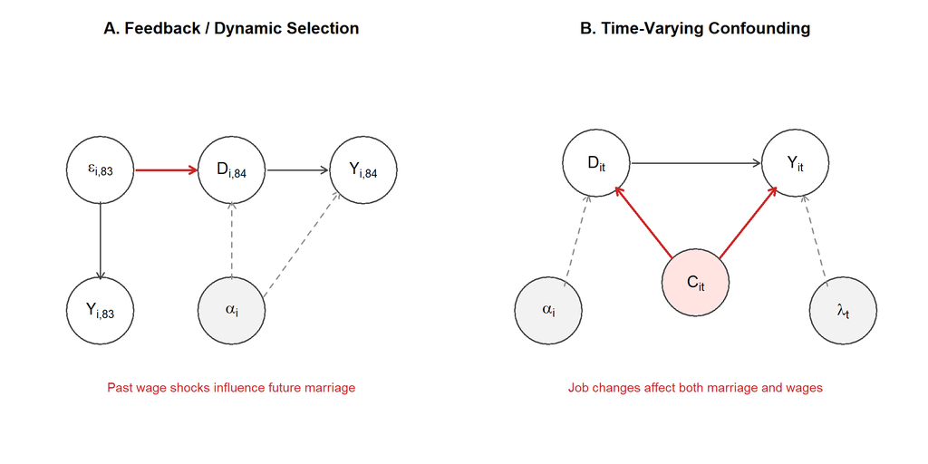

#### Testing Strict Exogeneity: Add the Lead

Under FE.1, next year’s treatment cannot predict this year’s outcome once $\alpha_i$ and this year’s treatment are held fixed

### FE.3 assumes homoskedasticity and no serial correlation.

1. **Homoskedasticity**: The conditional variance of the error term is constant across individuals and time periods.
2. **No Serial Correlation**: The error terms for the same individual are uncorrelated across different time periods, conditional on the explanatory variables and individual fixed effects.

Violating FE.3 does not necessarily bias FE coefficient estimates or make them inconsistent, provided the other required assumptions hold. However, it can invalidate conventional standard errors and statistical inference. Cluster-robust standard errors can address these violations.

## Random Trends

### Example: When Men on Steeper Paths Marry

Hypothetical, no noise, and **marriage has no effect at all**. Fitted by two-way FE:

```
TWFE estimate: 0.118
```

```
With individual slopes: 0
```

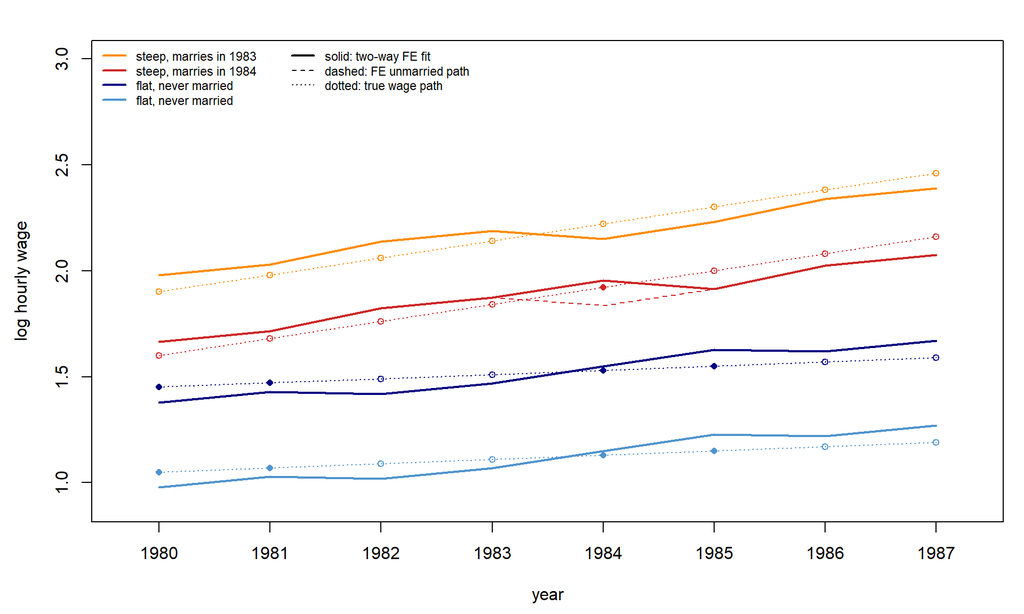

### Each Man His Own Slope

FE allows men to differ in wage *levels*. If men on steeper wage paths marry, FE still mistakes their growth for a marriage effect.

The **random trend model**/**FEIS** (fixed effects with individual slopes) gives each man his own line:

$$Y_{it}=\alpha_i+\gamma_i x_{it}+\lambda_t+\beta D_{it}+\epsilon_{it}$$

Own intercept $\alpha_i$, own slope $\gamma_i$ in experience $x$.

Year effects stay: own lines absorb differences in *growth* between men; $\lambda_t$ absorbs shocks common to a year (a recession), which lie on no one’s line.

Estimate $\beta$ in three steps:

1. For each man, regress his wages on $(1,x_{it})$ using only his own years. Keep the residuals $\ddot{Y}_{it}$: his departures from his own line.
2. Do the same for marriage, giving $\ddot{D}_{it}$, and for each year dummy.
3. Pool all men and regress $\ddot{Y}_{it}$ on $\ddot{D}_{it}$ and the detrended year dummies.

Fixed effects is the same recipe with a line of slope zero: step 1 subtracts only his mean.

- It detrends each unit separately, then pool
- Needs at least three observations per unit.
- Identifies $\beta$ from departures from each man’s own trajectory at marriage: a jump, not a steeper path.

**Warning**

an FE impact function that keeps rising after the event is a warning sign of selection on slopes

## Two-Way Fixed Effects: Strengths and Weaknesses $\bigstar$

**Strengths**

- Removes every stable trait of the unit, *measured or not*.
- Removes everything common to a year.
- Simple and transparent: a difference-in-differences with many units and periods.
- Testable in part: leads (no feedback), event studies.

**Weaknesses**

- Needs strict exogeneity: no feedback, nothing else changing at the same time.
- Misses differences in *growth*: men on steeper paths (FEIS).
- Only units whose treatment changes identify $\beta$, weighted by how much it varies.
- Less precise; measurement error grows. **Cluster by unit.**
- With a lagged outcome: Nickell bias (below).

### Put Last Year’s Outcome in a Fixed-Effects Model

Marriage can follow wages, not only the other way round: a good year makes a man more likely to marry next year, and wages persist. So control for last year’s wage:

$$Y_{it}=\rho Y_{i,t-1}+\beta D_{it}+\alpha_i+\epsilon_{it}$$

This compares men who start the year at the same wage, one who marries and one who does not; $\alpha_i$ still removes everything stable about the man.

**Other questions where the outcome feeds back into the treatment:**

- **Health and employment:** illness leads to job loss; job loss worsens health.
- **Parental help and test scores:** parents step in after a bad report card.
- **Policing and crime:** cities hire police after a crime spike; crime persists.

The catch: with $\alpha_i$ in the model, a lagged outcome breaks strict exogeneity.

Sociologists often control for last year’s outcome, to absorb differences between units that are *changing* rather than fixed. Combining it with unit fixed effects creates a new bias (Nickell).

**NoteNickell Bias**

The outcome depends on its own past:

$$Y_{it}=\rho Y_{i,t-1}+X_{it}'\beta+\alpha_i+\epsilon_{it}.$$

FE.1 fails by construction: $Y_{i,t-1}$ contains $\epsilon_{i,t-1}$, which is in $\bar{\epsilon}_{i\cdot}$. Demeaned lag and demeaned error are correlated (Nickell 1981):

$$\operatorname{plim}_{N\to\infty}\hat{\rho}_{FE}-\rho
\approx -\frac{1+\rho}{T-1}
\qquad \text{large-}T\text{ approximation; exact formula in the script}$$

| Simulation, $\rho=0.5$, $N=500$, 200 draws | $T=4$ | $T=8$ | $T=16$ |
| --- | --- | --- | --- |
| Mean of $\hat{\rho}_{FE}$ | $-0.04$ | $0.27$ | $0.40$ |
| Nickell’s exact fixed-$T$ value | $-0.04$ | $0.27$ | $0.39$ |

Large $N$ does not help; only large $T$ does.

**Solutions**

- Anderson–Hsiao: Difference, Then Instrument
- Arellano–Bond: Use Every Valid Lag

# Random Effects

## Question

**Goal:** the same model whenever members share a group (students in a school, siblings in a family, workers in a firm, the years of one life):

$$Y_{ij}=\alpha_j+\beta X_{ij}+\epsilon_{ij}.$$

|  | Assumption on $\alpha_j$ | Uses |
| --- | --- | --- |
| Fixed effects | None: $\alpha_j$ may covary with $X$ | Within groups only |
| Random effects | $\operatorname{Cov}(\alpha_j,X_{ij})=0$, all $i$: unrelated to $X$ | Within and between |

- Both let $\alpha_j$ vary across groups. The names mislead: the key difference is whether $\alpha_j$ may covary with $X$ (Wooldridge 2010, ch. 10).
- If it may not, random effects is more precise and estimates group-level variables.

## Visualization

Six groups, $\beta=1$; same $\operatorname{Var}(\alpha_j)$ in both worlds, only its covariance with $X$ differs:

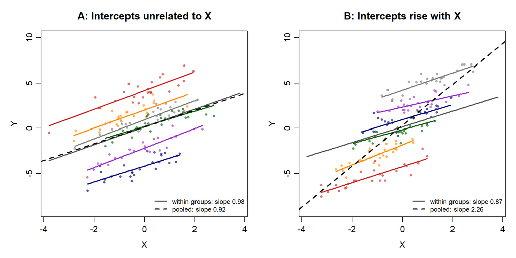

## Formula

Start from the model, average it over the group’s members, and subtract a share $\theta$ of that average:

$$\begin{aligned}
Y_{ij}
&=\beta X_{ij}+\alpha_j+\epsilon_{ij}
&& \text{the model}\\[4pt]
\bar{Y}_j
&=\beta\bar{X}_j+\alpha_j+\bar{\epsilon}_j
&& \text{average over group }j\text{'s members}\\[4pt]
Y_{ij}-\theta\bar{Y}_j
&=\beta(X_{ij}-\theta\bar{X}_j)
+(1-\theta)\alpha_j+(\epsilon_{ij}-\theta\bar{\epsilon}_j)
&& \text{line 1 minus }\theta\times\text{ line 2}
\end{aligned}$$

| $\theta$ | Estimator | Share of $\alpha_j$ left in the error |
| --- | --- | --- |
| $0$ | Pooled OLS | All |
| Between $0$ and $1$ | Random effects | $1-\theta$ |
| $1$ | Fixed effects | None |

- For $\theta<1$, a share $(1-\theta)$ of $\alpha_j$ stays in the error. That is harmless only if $\alpha_j$ is unrelated to $X$: the **random-effects assumption**.

Random effects picks $\theta$ from two variances, $\tau^2=\operatorname{Var}(\alpha_j)$ and $\sigma^2=\operatorname{Var}(\epsilon_{ij})$, with $n$ members per group:

$$\theta=1-\sqrt{\frac{\sigma^2}{\sigma^2+n\tau^2}}
\qquad \text{(GLS; Wooldridge 2010, ch. 10).}$$

- The group mean $\bar{Y}_j$ carries $\alpha_j$ plus noise of variance $\sigma^2/n$.
- Many members or large group differences ($n\tau^2\gg\sigma^2$): the group mean is mostly $\alpha_j$, so remove nearly all of it, $\theta\to1$, like fixed effects.
- Few members or small group differences: the group mean is mostly noise, so remove little of it, $\theta\to0$, like pooled OLS.

| $\sigma=1.5,\ \tau=2$ | $n=1$ | $n=4$ (simulation) | $n=20$ |
| --- | --- | --- | --- |
| $\theta$ | 0.40 | $1-\sqrt{2.25/18.25}=0.65$ | 0.84 |

## Testing Fixed Against Random: Hausman

$H_0$: $\alpha_j$ is unrelated to $X$ (Hausman 1978). Fixed effects is consistent either way; random effects is consistent and more precise under $H_0$, inconsistent otherwise.

$$H=\frac{(\hat{\beta}_{FE}-\hat{\beta}_{RE})^2}
{\operatorname{Var}(\hat{\beta}_{FE})-\operatorname{Var}(\hat{\beta}_{RE})}
\xrightarrow{d}\chi_1^2$$

- **Numerator:** how far apart the two estimates are. Under $H_0$ both are right, so they should differ only by noise.
- **Denominator:** how much noise to expect. Under $H_0$ random effects is the most precise, so $\operatorname{Var}(\hat{\beta}_{FE}-\hat{\beta}_{RE})=\operatorname{Var}(\hat{\beta}_{FE})-\operatorname{Var}(\hat{\beta}_{RE})$.
- **Large** $H$: the gap is more than noise, so reject random effects. In the 1,000 simulated samples it rejects 5.6% of the time in world A, 100% in world B.

Marriage data: $\chi_{10}^2=37.0$, $p<0.001$. Caveat: the denominator assumes random effects is fully efficient, which fails when errors are serially correlated.

## FE vs RE: How to Choose

| If the question is | Use |
| --- | --- |
| The effect of a member-level variable, and the group effect may be confounded | Fixed effects |
| The effect of a group-level variable (school sector) | Random effects (fixed effects cannot estimate it), which needs $\alpha_j$ unrelated to every regressor |
| How much variation lies between groups (Week 4’s ICC) | Random effects |

- Not rejecting does not make fixed effects wrong: it stays consistent either way.
- Fixed effects is not automatically causal: it removes only what group members share.

# DID

**TipA Comprehensive Course (Free Slides) on DiD by Pedro H. C. Sant’Anna**

https://psantanna.com/did-resources/#/

## The Canonical 2 × 2 $\bigstar$

Two groups, two periods. One group is treated in period 2.

|  | Before | After | Difference |
| --- | --- | --- | --- |
| Treated | $E[Y\mid g=1,t=1]$ | $E[Y\mid g=1,t=2]$ | $\Delta_1$ |
| Control | $E[Y\mid g=0,t=1]$ | $E[Y\mid g=0,t=2]$ | $\Delta_0$ |
|  |  |  | $\tau=\Delta_1-\Delta_0$ |

- The first difference removes anything fixed about each group.
- The second difference removes anything common to both groups over time.
- Equivalent regression: $Y_{it}=\alpha+\gamma\,\text{treated}_i+\delta\,\text{post}_t+\tau(\text{treated}_i\times\text{post}_t)+\epsilon_{it}$.

## The 2 × 2 in Regression Form

Group $g_i\in\{0,1\}$, period $t\in\{1,2\}$; the four cell means follow:

$$Y_{it}=\alpha+\gamma g_i+\delta\,\text{post}_t+\tau(g_i\times\text{post}_t)+\epsilon_{it}.$$

|  | Before | After | Difference |
| --- | --- | --- | --- |
| Treated ($g=1$) | $\alpha+\gamma$ | $\alpha+\gamma+\delta+\tau$ | $\delta+\tau$ |
| Control ($g=0$) | $\alpha$ | $\alpha+\delta$ | $\delta$ |
|  |  |  | $\tau$ |

- $\gamma$ absorbs fixed differences in level; $\delta$ absorbs the common time trend; $\tau$ is what is left.
- Unit and period fixed effects in place of $g_i$ and $\text{post}_t$: two-way FE, **identical with two groups and two periods**, not otherwise.

## Parallel Trends $\bigstar$

**The identifying assumption**

$$E[Y_{i2}(0)-Y_{i1}(0)\mid g_i=1]
=
E[Y_{i2}(0)-Y_{i1}(0)\mid g_i=0].$$

*Absent treatment*, the two groups’ average outcomes would have moved in parallel.

- Levels may differ arbitrarily. Only the *trends* in the untreated potential outcome must agree.
- **Untestable:** it concerns a counterfactual trend. Pre-treatment parallelism is suggestive evidence, not proof.
- **Not scale-free:** parallel trends in levels and parallel trends in logs are different assumptions, and both cannot generally hold.
- Needs **no anticipation:** units must not change behaviour before treatment in expectation of it.

**WarningParallel Trends Is Not Scale-Free**

Suppose untreated outcomes would have grown by 10% in both groups, from a base of 20 in the treated group and 40 in the control group.

|  | Before | After | Change |
| --- | --- | --- | --- |
| Treated | 20 | 22 | +2 |
| Control | 40 | 44 | +4 |

- Parallel trends holds **in logs** (both +10%) but **fails in levels** (+2 versus +4). A DID in levels would report a spurious $-2$.
- Here both hold only if base levels are equal or nothing grows. **There is no neutral choice:** the transformation is part of the identifying assumption.
- Choose before looking at results: would untreated outcomes grow by the same amount, or the same percentage? It matters most when levels are far apart.

**When Does the Scale Not Matter?**

Parallel trends holds for every monotone transformation of Y if and only if the whole distribution of $Y(0)$ satisfies a parallel-trends condition. In practice: the population splits into a part where treatment is as good as random and a part whose $Y(0)$ distribution does not change over time.

- In any real DiD the scale is therefore part of the assumption. Choose it before seeing results, on substantive grounds
- The condition can be falsified in the pre-period: compare the groups’ outcome distributions, not only means.
- For effects on whole distributions under weaker assumptions: Callaway and Li (2019).

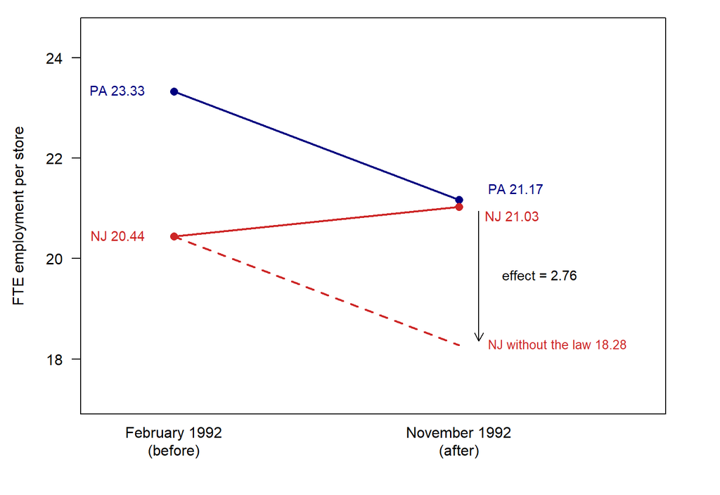

### Decomposition of Estimations $\bigstar$

Decompose the treated group’s observed change. Its period-2 outcome is $Y_{i2}(1)$, its period-1 outcome is $Y_{i1}(0)$ (no anticipation); add and subtract the counterfactual $Y_{i2}(0)$:

$$\begin{aligned}
\Delta_1
&=E[Y_{i2}(1)-Y_{i1}(0)\mid g_i=1]\\
&=\underbrace{E[Y_{i2}(1)-Y_{i2}(0)\mid g_i=1]}_{\text{ATT}}
+\underbrace{E[Y_{i2}(0)-Y_{i1}(0)\mid g_i=1]}_{\text{treated group's untreated trend}}.
\end{aligned}$$

The control group supplies an estimate of that second, unobservable term:

$$\Delta_0=E[Y_{i2}(0)-Y_{i1}(0)\mid g_i=0].$$

Subtracting,

$$\boxed{
\Delta_1-\Delta_0
=
\text{ATT}
+
\underbrace{
E[\Delta Y(0)\mid g=1]
-
E[\Delta Y(0)\mid g=0]
}_{\text{differential trend; }=0\text{ under parallel trends}}
}$$

- The estimand is the **ATT**, not the ATE: we borrowed a counterfactual trend *for the treated group*. Nothing in the design identifies what treatment would have done to the controls.
- The bias term *is* the parallel-trends violation, exactly. Every diagnostic for DiD is aimed at that one object.

# Staggered DID

## Staggered Setting $\bigstar$

The $2\times 2$ with many periods: **units adopt the policy at different times** (states pass a law in 1995, 2001, 2008). The standard specification is the $2\times 2$ regression, extended:

$$Y_{it}=\alpha_i+\lambda_t+\beta D_{it}+\epsilon_{it},
\qquad
D_{it}=\mathbb{1}\{t\geq G_i\}.$$

For thirty years this was assumed to estimate “the” treatment effect. It does when the effect is **constant across units and over time since treatment**. With heterogeneous or dynamic effects it need not estimate any sensible average.

## Example: Marriage Data $\bigstar$

The panel section’s TWFE (545 men, 1980–87, $\hat{\beta}=0.061$) is this setting: men marry in different years. Each man falls into one group:

| Group | Men | Role in TWFE |
| --- | --- | --- |
| Never married, 1980–87 | 162 | Never treated |
| Married all 8 years | 73 | Always treated |
| Marry in 1981, $\ldots$, 1987 and stay married | 239 | Staggered: 51, 33, 40, 27, 30, 27, 31 |
| Marry, then leave marriage | 71 | Switches off: not staggered |

- Staggered adoption needs $D$ to stay on once it starts. That holds for 474 of the 545 men; the 71 who leave marriage are an on/off design (Beyond 0/1 section).
- TWFE compares, for example, men who marry in 1985 with men who stay single (*clean*), and with men who married in 1981 (*already treated*).
- So the 0.061 rests on parallel trends *and* on a marriage premium that does not grow or fade with years married. If it does, the forbidden comparison bites.

## The Forbidden Comparison $\bigstar$

**Important**

The TWFE estimate is a weighted average of *all possible* 2 × 2 DID comparisons in the data, including comparisons that use **already-treated units as controls**.

Before the real data, a toy with no noise. Three units, four periods. The outcome without treatment is **0 for everyone**, so every number above 0 is a treatment effect:

| Unit | $t=1$ | $t=2$ | $t=3$ | $t=4$ |  |
| --- | --- | --- | --- | --- | --- |
| Early | 0 | **1** | **2** | **3** | Treated from $t=2$; effect grows 1, 2, 3 |
| Late | 0 | 0 | 0 | **1** | Treated from $t=4$; effect 1 |
| Never | 0 | 0 | 0 | 0 | Never treated |

- **Bold cells are treated.** Early’s effect keeps growing the longer it is treated.
- Every effect is positive. Late’s effect in $t=4$ is exactly 1.

A $2\times 2$ that TWFE uses: *late* is the treated unit, *early* the control. Before $=t=2$ (late untreated); after $=t=4$ (late treated).

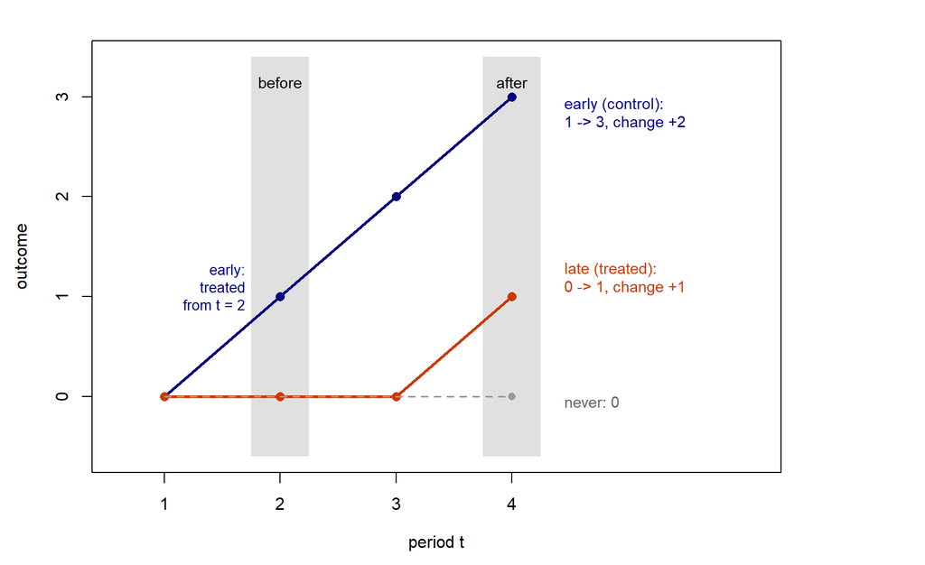

Early is treated at both dates, so its line rises for one reason: its own effect grows from 1 to 3.

|  | Before: $t=2$ | After: $t=4$ | Change |
| --- | --- | --- | --- |
| Late (treated) | 0 | 1 | $+1$ |
| Early (control) | 1 | 3 | $+2$ |
| $2\times2=$ late’s change $-$ early’s change |  |  | $1-2=-1$ |

## The Goodman-Bacon Decomposition (not evaluated)

TWFE is a weighted average of every $2\times2$ in the data:

$$\hat{\beta}^{\mathrm{TWFE}}
=
\sum_{\text{pairs}}s_{ab}\hat{\beta}_{ab}^{2\times2},
\qquad
\sum_{\text{pairs}}s_{ab}=1.$$

- **The** $2\times2$s: treated vs. never (clean); earlier vs. later, before later switches (clean); **later vs. earlier, after earlier switches (forbidden)**.
- **The weights:** how much data the pair uses $\times$ variance of $D$ in the pair, the same rule as the panel section’s $Tp_i(1-p_i)$.

**What the weights imply**:

Every weight has the $p(1-p)$ shape of a Bernoulli variance, so **groups treated near the middle of the panel dominate**: the weights come from OLS mechanics, not from group sizes alone and not from any estimand you chose (Week 1’s variance weighting).

The forbidden comparison uses the periods after early switches. Its weight is larger when early switched early (a long stretch) and late switches halfway through it ($p=1/2$). That stretch holds early’s long-run effects: the ones it subtracts.

All of this is computable from the data alone: `bacondecomp::bacon()` lists every $2\times2$, its estimate, and its weight.

## Decomposition of Weights

Early (treated) vs. late (control), periods 1–3, while late is still untreated:

|  | $t=1$ | $t=2$ | $t=3$ |
| --- | --- | --- | --- |
| Early: $D$ | 0 | 1 | 1 |
| Early: $Y$ | 0 | 1 | 2 |
| Late: $D$ and $Y$ | 0 | 0 | 0 |

$$\begin{aligned}
2\times2
&=\left[\frac{1+2}{2}-0\right]-[0-0]=1.5
&& \text{before }t=1,\text{ after }t=2,3\\[6pt]
\operatorname{Var}(D)
&=p(1-p)=\frac{2}{3}\cdot\frac{1}{3}=0.222
&& \text{early has }D=1\text{ in 2 of 3 periods}\\[6pt]
\text{Size}
&=(3/4)^2=0.5625
&& \text{uses 3 of the 4 periods, squared}\\[6pt]
\text{Raw weight}
&=0.5625\times0.222=0.125
\end{aligned}$$

$p(1-p)$ is the panel section’s $p_i(1-p_i)$: **largest when the treated group is treated half the time**. Equal group sizes, so they cancel.

Same steps for every pair; weight = raw weight / sum:

| Comparison | $2\times2$ | Periods | $p(1-p)$ | Raw weight | Weight |
| --- | --- | --- | --- | --- | --- |
| Early vs. never | 2.0 | 1–4 | $\frac{3}{4}\cdot\frac{1}{4}$ | $1\times0.1875=0.1875$ | 0.3 |
| Late vs. never | 1.0 | 1–4 | $\frac{1}{4}\cdot\frac{3}{4}$ | $1\times0.1875=0.1875$ | 0.3 |
| Early vs. late | 1.5 | 1–3 | $\frac{2}{3}\cdot\frac{1}{3}$ | $\frac{9}{16}\times0.222=0.125$ | 0.2 |
| Late vs. early | $-0.5$ | 2–4 | $\frac{1}{3}\cdot\frac{2}{3}$ | $\frac{9}{16}\times0.222=0.125$ | 0.2 |
| **Sum** |  |  |  | **0.625** | **1** |

- **Weighted sum:** $0.3(2)+0.3(1)+0.2(1.5)+0.2(-0.5)=1.10$. The TWFE regression on the 12 cells gives **1.10**; `bacon()` gives the same pieces.
- **True average effect on the treated cells:** 1.75.

## Fix

**Important**

TWFE is fine when treatment timing is common, or when effects are genuinely constant. It is unreliable exactly where sociologists use it most.

### Clean 2 × 2s, Then One Average $\bigstar$

All of them share one principle: **never use an already-treated unit as a control**. Build clean 2 × 2 comparisons, then aggregate with weights you choose.

| Method | Idea | R |
| --- | --- | --- |
| Callaway–Sant’Anna (2021) | $\operatorname{ATT}(g,t)$; never- or not-yet-treated controls | `did` |
| Sun–Abraham (2021) | CS’s blocks as one regression (Event Studies) | `fixest::sunab` |
| de Chaisemartin–D’Haultfoeuille | Clean comparisons at switch dates | `DIDmultiplegt` |
| Borusyak–Jaravel–Spiess | Impute $Y(0)$ from untreated cells | `didimputation` |

# Event Studies

## The Idea $\bigstar$

$D_{it}$ is still binary: 0 before unit $i$ starts, 1 from then on. The static TWFE puts one $\beta$ on $D_{it}$: every cohort and every year since the start, averaged into one number. The event study estimates one effect per period relative to the start:

$$Y_{it}=\alpha_i+\lambda_t+\sum_{k\neq-1}\tau_k\cdot\mathbb{1}\{t-G_i=k\}+\epsilon_{it},$$

where $G_i$ is unit $i$’s treatment date (for example, the year a man marries) and $k=-1$ is the omitted reference.

- **Pre-period coefficients** ($k<0$) are the parallel-trends check. Flat and near zero is what you want to see.
- **Post-period coefficients** trace out the dynamics: does the effect grow, fade, or appear only after a lag?
- **Caution:** with staggered $G_i$, the event study can inherit the forbidden comparison (end of this section).

## Each $\tau_k$ Is a 2 × 2 Against Period $k = −1$ $\bigstar$

Treated units start at $G=0$, so $k=t$; controls never start. Plug in, dropping $\epsilon$:

|  | $t=-2$ | $t=-1$ (base) | $t=0$ (start) | $t=1$ |
| --- | --- | --- | --- | --- |
| Treated | $\alpha_T+\lambda_{-2}+\tau_{-2}$ | $\alpha_T+\lambda_{-1}$ | $\alpha_T+\lambda_0+\tau_0$ | $\alpha_T+\lambda_1+\tau_1$ |
| Control | $\alpha_C+\lambda_{-2}$ | $\alpha_C+\lambda_{-1}$ | $\alpha_C+\lambda_0$ | $\alpha_C+\lambda_1$ |

Two-period DiDs against $t=-1$ ($\alpha$ cancels in a row, $\lambda$ across rows):

$$\begin{aligned}
\text{pre},\ t=-2\text{ vs. }-1:\quad
&(\lambda_{-2}-\lambda_{-1}+\tau_{-2})
-(\lambda_{-2}-\lambda_{-1})=\tau_{-2}\\[6pt]
\text{start},\ t=0\text{ vs. }-1:\quad
&(\lambda_0-\lambda_{-1}+\tau_0)
-(\lambda_0-\lambda_{-1})=\tau_0\\[6pt]
\text{post},\ t=1\text{ vs. }-1:\quad
&(\lambda_1-\lambda_{-1}+\tau_1)
-(\lambda_1-\lambda_{-1})=\tau_1
\end{aligned}$$

- An event study is a set of two-period DiDs that share one base period, $t=-1$.
- **Pre:** $\tau_{-2}$ should be 0; if not, the groups were already drifting apart. **From** $t=0$ on: the usual DiD effect; $t=0$ is already treated.

## The Event Study on the Toy Example $\bigstar$

Toy: 2 treated, 2 control units, periods 1–6; $D: 0\rightarrow1$ at period 4. Titles: the one-number TWFE $\hat{\beta}$ .

- **Growing vs. fading:** same $\hat{\beta}$, opposite paths; the event study separates them.
- **Trend:** leads $-0.8,-0.4$ already slope up, and the “effects” $0.4,0.8,1.2$ continue the same line. The picture warns you; $\hat{\beta}=1.2$ did not. This is Ludwig and Brüderl’s marriage premium: future husbands were already on steeper paths; FE 8.3% and rising, FEIS 0.5%.
- **More transparent, not more causal:** the leads check only the pre-period; the lags are effects only if trends would have stayed parallel *after* adoption, which no data can show.

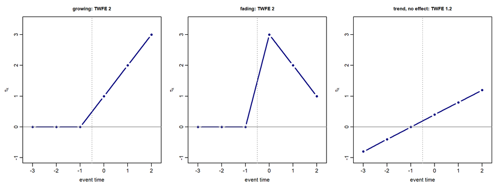

The staggered toy: early starts at $t=2$ with effects **1, 2, 3** (growing), late at $t=4$ with effect 1. The forbidden $2\times2$, late vs. early, $t=3\rightarrow4$:

|  | Change, $t=3\rightarrow4$ | Static TWFE reads it as | Event study reads it as |
| --- | --- | --- | --- |
| Late (treated) | $0\rightarrow1:\ +1$ | $\beta$ | $\tau_0$ |
| Early (control) | $2\rightarrow3:\ +1$ | $\beta-\beta=0$ | $\tau_2-\tau_1$ |
| $2\times2$ | $1-1=0$ | $0=\beta$ | $0=\tau_0-(\tau_2-\tau_1)$ |

- **Static TWFE** thinks early’s effect is constant, so early’s $+1$ must be the common trend. It reads the $2\times2$ as $\beta=0$, and is pulled down: 1.10, not 1.75.
- **The event study** knows early moved from $k=1$ to $k=2$, and that its effect grew by $\tau_2-\tau_1=3-2=1$. It subtracts that growth: $\tau_0=0+1=1$. Correct.
- The TWFE event study gives exactly **1, 2, 3**: it **fixes the growing-effect problem**.

## Reading the Event-Study Equation

One man married in 1984 ($G_i=1984$), observed 1980–87. $k=t-G_i$ is years since marriage:

| Year $t$ | 1980 | 1981 | 1982 | 1983 | 1984 | 1985 | 1986 | 1987 |
| --- | --- | --- | --- | --- | --- | --- | --- | --- |
| $k=t-1984$ | $-4$ | $-3$ | $-2$ | $-1$ | $0$ | $1$ | $2$ | $3$ |
| Dummy that is 1 | $\tau_{-4}$ | $\tau_{-3}$ | $\tau_{-2}$ | None | $\tau_0$ | $\tau_1$ | $\tau_2$ | $\tau_3$ |

- Each year switches on **exactly one dummy**, except $k=-1$, the reference: every $\tau_k$ compares year $k$ with the year before marriage.
- A man who never marries has every dummy 0: he only helps estimate $\alpha_i$ and $\lambda_t$.
- $\tau_{-4},\tau_{-3},\tau_{-2}$: marriage cannot have caused anything yet, so they should be near 0.

## Specification Details That Matter

Three choices inside the specification change the picture; report each.

- **Normalization:** one lead must be omitted (here $k=-1$). Every $\tau_k$ is relative to it, so the picture shifts if you change the reference period. Say which you used.
- **Binning the endpoints:** with unbalanced exposure, far leads and lags are estimated off few units. Bin them ($k\leq-5$, $k\geq5$) or restrict to a balanced window, and say which.
- **Never-treated units** anchor the time effects $\lambda_t$.

## Event Study Assumptions $\bigstar$

To subtract early’s growth from late’s comparison, the event study assumes **every cohort follows the same path** $\tau_0,\tau_1,\tau_2$: one $\tau_k$ for all.

**Break it:** keep early at 1, 2, 3, but late gains 3 at $k=0$. Early vs. never says $\tau_0=1$, late vs. never says 3; one $\tau_0$ cannot be both, and the misfit leaks:

| $k$ | $-3$ | $-2$ | $0$ | $1$ | $2$ |
| --- | --- | --- | --- | --- | --- |
| Truth (average over cohorts) | 0 | 0 | 2 | 2 | 3 |
| TWFE event study | $-0.75$ | $-0.25$ | 2.00 | 2.75 | 3.25 |
| Clean blocks (vs. never, base $g-1$) | 0 | 0 | 2 | 2 | 3 |

- A **fake pre-trend and wrong post effects**, from treatment effects alone: the forbidden $2\times2$ is still in the regression (Sun and Abraham 2021).
- **Why the leads move:** late jumps 3, the shared $\hat{\tau}_0$ is 2, so OLS raises late’s level ($\hat{\alpha}=0.75$); the leads go negative to pull its before-years back to 0.
- **Fix:** give each cohort its own path, then average by $k$.

### Sun–Abraham: the Same Blocks, as One Regression

Sun and Abraham (2021)’s fix for the event study: do not force one $\tau_k$ on all cohorts. Interact event time with cohort:

$$Y_{it}
=
\alpha_i+\lambda_t+
\sum_g\sum_{k\neq-1}
\delta_{gk}\,\mathbb{1}\{G_i=g\}\mathbb{1}\{t-g=k\}
+\epsilon_{it}$$

- $\delta_{gk}$: cohort $g$’s effect $k$ years after starting, one coefficient per block.
- Then average across cohorts at each $k$, weighted by cohort size (`fixest::sunab`).

|  | Sun–Abraham | Callaway–Sant’Anna |
| --- | --- | --- |
| How | One regression | Separate $2\times2$s |
| Controls | Never (or last) treated | Never or not-yet treated |
| Covariates | Linear, in the regression | OR, IPW, or DR in each block |

Same controls, no covariates: identical estimates (divorce data: both $-6.5$ over $k=0$–$10$; one overall number, both $-10.56$).

## Choices Every Staggered DiD Makes

| Choice | Options | Consequence |
| --- | --- | --- |
| Comparison group | Never treated; not yet treated | Not-yet uses more data but needs no anticipation and parallel trends with future adopters |
| Baseline | $g-1$ only; all pre-periods | All pre-periods is efficient if trends are parallel throughout, biased if not |
| Aggregation | Simple; by event time; by cohort; by calendar time | Each is a different estimand; say which |
| Anticipation | Shift $g$ back by $\delta$ periods | Otherwise effects leak into the baseline |
| Covariates | None; DR within each $ATT(g,t)$ | Use pre-treatment values only |
| Inference | Cluster; bootstrap; randomization | Few treated cohorts need care |

Efficiency when adoption timing is as good as random: Roth and Sant’Anna (2023b) (`staggered`). A design-based reading of TWFE under random timing: Athey and Imbens (2022).

# Beyond 0/1

## TWFE Gets Run on Any Treatment $\bigstar$

In sociology $Y_{it}=\alpha_i+\lambda_t+\beta D_{it}+\epsilon_{it}$ is run on almost anything that changes within a person:

- A **count or dose**: number of children (Budig and England), hours worked, neighborhood poverty rate;
- A **status that switches on and off**: married, cohabiting, union member, employed.

**How** $\hat{\beta}$ is read: “One more unit of $D$ raises $Y$ by $\beta$.” That reading needs four things:

1. The effect is **linear in** $D$: the first child does what the third one does;
2. It is **the same for every person**: no one chose $D$ because they gain more;
3. It is **the same at every time since the change**: no growth or fade-out;
4. **No carryover**: once $D$ goes back down, the past dose stops mattering.

**What** $\hat{\beta}$ actually is: a weighted average of comparisons between people whose $D$ changed by different amounts at different times, already-changed people included as controls.